# Anger Graph

Valerie Monbet

1/10/2017

The raw data consist of the binary judgments of 101 first-year psychology students who indicated whether or not they would display each of 8 anger-related behaviors when being angry at someone in each of 6 situations.

- The 8 behaviors consist of 4 pairs of reactions that reflect a particular strategy to deal with situations in which one is angry at someone, namely,
1. fighting (fly off the handle, quarrel),
2. fleeing (leave, avoid),
3. emotional sharing (pour out one’s heart, tell one’s story),
4. making up (make up, clear up the matter).
- The six situations are constructed from two factors with three levels:
1. the extent to which one likes the instigator of anger (like, dislike, unfamiliar)
2. the status of the instigator of anger (higher, lower, equal).

Each situation is presented as one level of a factor, without specifying a level for the other factor.

```r
library(plfm)
data(anger)
D = anger$data
```

## Ising model graphs for situation

Plot a graph based on the Ising model pour the subset of the data of situation “like”.

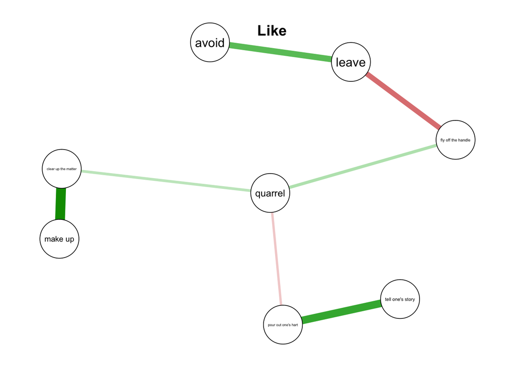

```r
library(IsingFit)
r.nb = 1 # "like"
D.subset = matrix(0,nrow(D),ncol(D[1,,]))
for (ii in 1:nrow(D)){
    D.subset[ii,] = c(D[ii,r.nb,])
}
D.subset = data.frame(D.subset)
colnames(D.subset) <- colnames(D[1,,])

mod.ising = IsingFit(D.subset,gamma=.25)
title("Like")
```

Question: What are the conditionnal independence describd by this graph?

This result can be compared to some plots from the MCA (multivariate correspondance analysis)

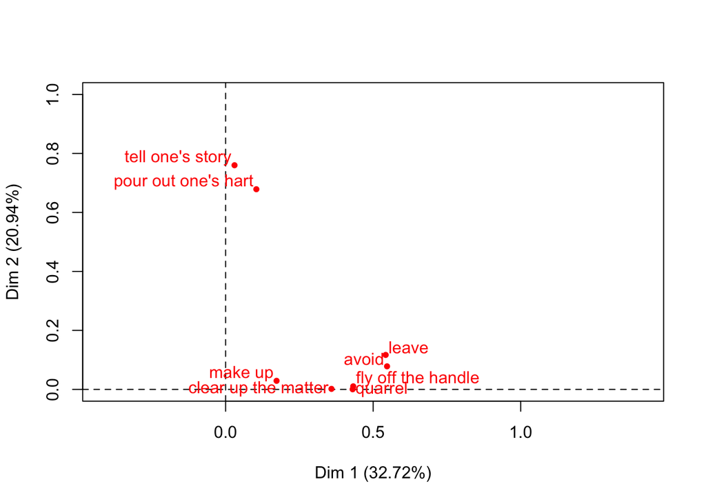

```r
library(FactoMineR)
mca = MCA(apply(D.subset,2,as.factor),graph=FALSE)
plot(mca,choix="var")
```

Question: What are the information on the MCA plot? Can retrieve some informations which help to understand the graph plot?

## Ising model graphs for behaviours

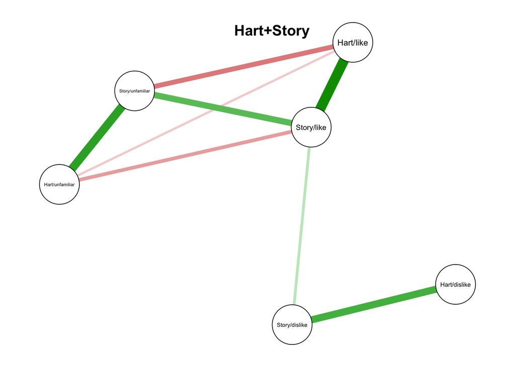

```r
c.nb = c(5,6) #
D.subset = matrix(0,nrow(D),6)
for (ii in 1:nrow(D)){
    D.subset[ii,] = c(D[ii,1:3,c.nb])
}
D.subset = data.frame(D.subset)
colnames(D.subset)[1:3] <- paste("Hart","/",rownames(D[1,1:3,]),sep="")
colnames(D.subset)[4:6] <- paste("Story","/",rownames(D[1,1:3,]),sep="")
mod.ising = IsingFit(D.subset,gamma=.01)
title("Hart+Story")
```

This result can be compared to some plots from the MCA (multivariate correspondance analysis)

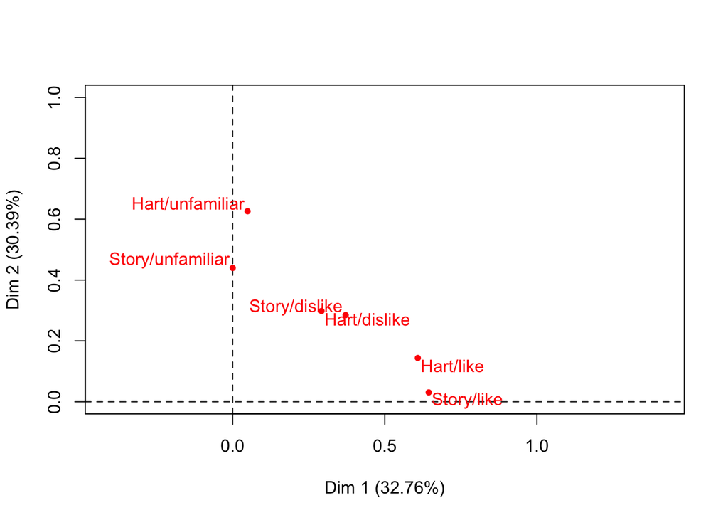

```r
library(FactoMineR)
mca = MCA(apply(D.subset,2,as.factor),graph=FALSE)
plot(mca,choix="var")
```

## Restricted Bolzman Machine

Restricted Bolzman Machines are usually used to pretrain deep neural network. However, they can also be used for dimension reduction and/or unsupervized learning.

Here, we will use the RBM from http://alandgraf.blogspot.fr/2013/01/restricted-boltzmann-machines-in-r.html?view=snapshot The visible and hidden units are bernoulli variables.

```r
source("https://perso.univ-rennes1.fr/valerie.monbet/GM/rbm.R")

set.seed("313")
rbm.anger = rbm(num_hidden=2,t(D[1:100,,1]),.01,1000,mini_batch_size=10,quiet=TRUE)

rbm.anger # weights
```

```
##            [,1]      [,2]       [,3]      [,4]       [,5]       [,6]
## [1,]  0.1980488 -1.090432 -1.1784443 -1.962488  1.4401220 -0.8475423
## [2,] -0.8635005 -1.172795 -0.1382069 -1.976021 -0.1528759 -1.1599088
```

Then probabilities of hidden state can be computed and hidden state predicted.

```r
proba = 1/(1+exp(-rbm.anger %*% t(D[1:20,,1]))) # visible_state_to_hidden_probabilities
proba
```

```
##      [,1]      [,2]       [,3]      [,4]      [,5]       [,6]      [,7]
## [1,]  0.5 0.6129493 0.34735061 0.8372859 0.8372859 0.12587058 0.4196239
## [2,]  0.5 0.2396529 0.08888074 0.2657338 0.2657338 0.08845042 0.0477705
##      [,8]      [,9]     [,10]     [,11]     [,12]      [,13]     [,14]
## [1,]  0.5 0.5493510 0.2353320 0.6439568 0.2999487 0.14932241 0.5865424
## [2,]  0.5 0.2966085 0.4655032 0.2120212 0.2386839 0.03930881 0.2098764
##            [,15]     [,16]     [,17] [,18]     [,19]     [,20]
## [1,] 0.031046337 0.1384841 0.3780455   0.5 0.4256055 0.6879663
## [2,] 0.004221608 0.1032507 0.0768753   0.5 0.0339253 0.1019004
```

```r
hidden_state = apply(proba,2,which.max)
print("Hidden states (or class)")
```

```
## [1] "Hidden states (or class)"
```

```r
hidden_state
```

```
##  [1] 1 1 1 1 1 1 1 1 1 2 1 1 1 1 1 1 1 1 1 1
```